# Concentration of Attacks on Civilians in Darfur

(2016 - 2021) - Visual 5

Rob Boswell

7-27-2023

- Previous Page
- Next Page

#### It can be seen that attacks on civilians from 2016 to 2018 were primarily concentrated in the region where the borders of Central, North, and South Darfur meet. However, the concentration of attacks substantially condensed into the southern part of North Darfur in 2019 - the year in which the UN formally decided to withdraw the entire mission - before suddenly expanding in 2020 mostly into the northeastern part of Central Darfur and also into West Darfur. The expansion into West Darfur is particularly noteable since a concentration of attacks there only started emerging in 2019.

#### In 2021, while the highest density of attacks on civilians shifted to the south-central part of North Darfur, the concentration of attacks in West Darfur still grew stronger.

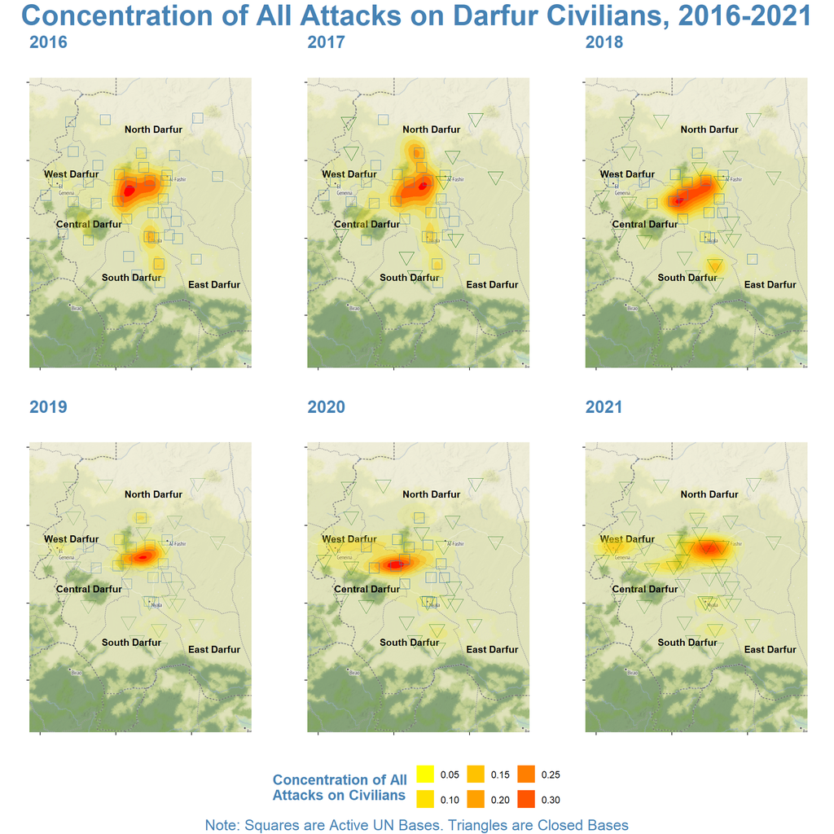

#### It is possible this expansion of the density of attacks into West Darfur may partly result from the UN closing 5 of its bases in the state from 2017-2019. Potential causes of this change in density deserve more inspection. In Visual 3, we saw an unusually large spike in civilian killings in Western Darfur (46) in 2019, and we saw that in 2021 there were more civilian killings there (155) than in any other state in Darfur. Although neither the 2019 nor the 2021 density maps in this visual show the highest concentration of attacks on civilians being in West Darfur, what may account for the discrepancy is that there was likely a larger than normal number of fatalities per attack in 2019 and 2021. We will investigate this further in Visual 7.

#### In the next visual, I will illustrate levels of violence against civilians in Darfur, overall, before vs. after UN troops withdrew.

- Previous Page
- Next Page